# Using R for Statistical Analysis of Survey Data

javaria

20 Dec 2020

# Herrarchial Clustering Using R

## Intro

R is a natural place to play with data and collections of natural / artificial data recorders, commonly in the form of electronic devices, ranging fromm cell phones to embedded platforms.

## Process

1. Install R
2. Prepare csv from input file (Excel .xlsx)
3. Start R

## Assignment

2. Excel Sheet to be downloaded from link provided
3. Perform MBA Using R and share most watched
4. Create appropriate visualizations to describe variables and answer the following questions :
   - Find top 3 movies?
   - Which age range likes superhero movies?
5. Using Hierarchial Clustering to find which gender / age group likes which of the top favourite movies?

## Solution

### Loading Excel Data

First Excel file needs to be converted to a CSV file by going to `File -> Save As` and selecting CSV (comma seperated values) as the format. Now it's time to load up R from any console and get to the R shell. The csv file can be loaded by calling `read.csv()` function

```r
DF<-read.csv('input.csv',sep=';')
head(DF)
```

```
##             Timestamp Age Gender favourite medium
## 1 11/27/2020 11:15:59  21
## 2 11/27/2020 11:16:07  21
## 3 11/27/2020 11:17:44  21
## 4 11/27/2020 11:19:07  24
## 5 11/27/2020 11:19:14  23
## 6 11/27/2020 11:21:03  22
##                                                                                                                                                                                                                                                                                                          …
## 1                                                                      Fast and Furious, Captain America, Avenger - End Game, Top Gun, Interstellar, Pirates of the Caribbean, Five Feet Apart, The Fault in Our Stars, The Dark Knight, Joker, The Pursuit of Happiness, Legend, Titanic, The Godfather,…
## 2                                                                                                     Fast and Furious, Gravity, Captain America, Avenger - End Game, Top Gun, Pirates of the Caribbean, The Dark Knight, Joker, Legend, Titanic, The Godfather, Mission Impossible, Lord of the Rings, M…
## 3                                                                                                                                                                                                                                                                                                        …
## 4 Contagion, Fast and Furious, Gravity, Captain America, Avenger - End Game, Top Gun, Interstellar, Pirates of the Caribbean, The Fault in Our Stars, The Dark Knight, Joker, The Pursuit of Happiness, Legend, Titanic, The Godfather, 7 pounds, Mission Impossible, Lord of the Rings, Matrix Reloaded,…
## 5                                                                                                                                                                                         Fast and Furious, Captain America, Avenger - End Game, Top Gun, Pirates of the Caribbean, Five Feet Apart, The …
## 6                                                                                                                                                                                                                                                                                                        …
```

The data from the file is now in the variable `DF` and the column names can be seen by calling `colnames()` function

```r
print(colnames(DF))
```

```
## [1] "Timestamp" "Age"       "Gender"    "favourite" "medium"    "list.."
```

### Perform MBA Using R and share most watched

By using builtin summary of the column "favourite movie" we find that the top 10 movies are :

```r
head(summary(DF$favourite),n=10)
```

```
##                   Batman Series   Interstellar            Joker        Avengers
##              39               5               4               4               3
## Captain america      Antonement Band baja barat    Harry Potter      Home alone
##               3               2               2               2               2
```

- Find top 3 movies?

```r
head(summary(DF$favourite),n=4)
```

```
##               Batman Series Interstellar          Joker
##            39             5             4             4
```

gnoring the first entry as it contains empty spaces in the survey dataset

```r
#DF$Age
#DF$Age<-as.integer(as.factor(DF$Age))
#DF$Age<-scale(DF$Age)

#for (col in colnames(DF)){
#print('Doing')
#print(col)
#DF[col]<-as.integer(as.factor(DF[col]))
#DF[col]<-scale(DF[col])
#}
```

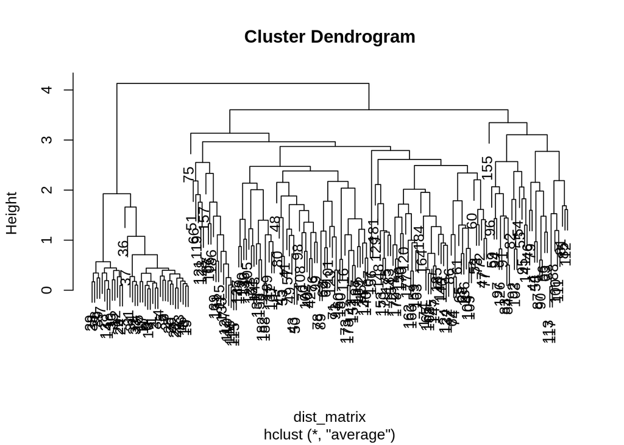

```r
for (col in 1:ncol(DF)){
#print('Doing')
#print(col)
DF[,col]<-as.integer(as.factor(DF[,col]))
DF[,col]<-scale(DF[,col])
}
#str(DF)
dist_matrix=dist(DF,method='euclidean')
hclust_avg=hclust(dist_matrix,method='average')
plot(hclust_avg)
```

```r
#cut_avg=cutree(hclust_avg,k=3)
#rect.hclust(hclust_avg,k=3,border=2:6)
#abline(h=3,col='red')
```

```r
#avg_dend_obj=as.dendrogram(hclust_avg)
#suppressPackageStartupMessages(library(dendextend))
#avg_col_dend=color_branches(avg_dend_obj,h=3)
#plot(avg_col_dend)
```